# ATAC-seq exploration practical

Pierre-Luc

2023/04/21

```r
suppressPackageStartupMessages({
  library(epiwraps)
  library(AnnotationHub)
  library(MotifDb)
  #library(memes)
  library(universalmotif)
  library(ensembldb)
  library(ggplot2)
})

ah <- AnnotationHub(localHub=TRUE)
ensdb <- ah[["AH89211"]] # mouse ensembldb object
```

## Download the data

```r
options(timeout=100000)
download.file("https://ethz-ins.org/content/w7/atac.chr19.bam", "atac.chr19.bam", mode = "wb")
download.file("https://ethz-ins.org/content/w7/atac.chr19.bam.bai", "atac.chr19.bam.bai", mode="wb")
```

```r
# if you're on a slow computer, you might also want to download the tracks that we're generating below:
download.file("https://ethz-ins.org/content/w7/w7_bw.zip", "w7_bw.zip")
unzip("w7_bw.zip")
```

## Preparing tracks

### BAMs and tracks

Notes: A BAM file contains - aligned sequencing reads and associated information, such as the mapping quality and read orientation, which can be used to generate a coverage track.

A coverage track - displays the number of reads that align to each position on the reference genome, providing a visualization of the sequencing depth and coverage across the genome. - useful for identifying regions of high and low coverage - additionally allows to visualize other features, e.g. - nucleosome-free regions

### Nucleosome free and nucleosome containing regions

Nucelosome-free regions can provide additonal information about the structure and organisation

- nucleosomes are the basic units in DNA packaging in eukaryotic cells
- NF regions are common near transcription start sites (TSSs)
- useful in understanding gene regulation, chromatin structure etc.

Nucleosome-containing regions can be identified by higher coverage in the coverage track as they contain nucleosomes that protect the DNA from digestion.

### Creating track files

To retrieve nucleosome-free and nucleosome-containing elements from the ATAC-seq data, we can use the coverage tracks generated from the BAM file.

We can use the bigWig file format to store the coverage tracks, and the rtracklayer package in R to read and manipulate them.

```r
bam <- "atac.chr19.bam"

# create a track using all fragments, computing the coverage at each position (and force Ensembl naming)
bam2bw(bam, output_bw = "full_cov.bw", paired=TRUE, binWidth=10L, forceSeqlevelsStyle = "Ensembl")

# create a track using all fragments, but computing the number of cuts/insertion sites at each position
epiwraps::bam2bw(bam, output_bw = "full_cuts.bw", paired=TRUE, binWidth=1L, type="ends",
                 shift=c(4L,-5L), forceSeqlevelsStyle = "Ensembl")

# create a track using only nucleosome-free fragments, computing coverage
bam2bw(bam, output_bw = "NF_cov.bw", paired=TRUE, binWidth=5L, minFragLength=30,
       maxFragLength=120, forceSeqlevelsStyle = "Ensembl")

# create a track using only nucleosome-free fragments, the number of cuts/insertion sites at each position
bam2bw(bam, output_bw = "NF_cuts.bw", paired=TRUE, binWidth=1L, type="ends", minFragLength=30,
       maxFragLength=120, shift=c(4L,-5L), forceSeqlevelsStyle = "Ensembl")

# create a track using only mono-nucleosome fragments, computing coverage
bam2bw(bam, output_bw = "mono_cov.bw", paired=TRUE, binWidth=10L, minFragLength=140,
       maxFragLength=220, forceSeqlevelsStyle = "Ensembl")

# create a track using only mono-nucleosome fragments, the number of cuts/insertion sites at each position
bam2bw(bam, output_bw = "mono_cuts.bw", paired=TRUE, binWidth=1L, type="ends", minFragLength=140,
       maxFragLength=220, forceSeqlevelsStyle = "Ensembl")

# create a track using only mono-nucleosome fragments, computing centers
bam2bw(bam, output_bw = "mono_centers.bw", paired=TRUE, binWidth=5L, minFragLength=140,
       maxFragLength=220, type="center", forceSeqlevelsStyle = "Ensembl")
```

## Obtaining the sites with a KLF4 motif

```r
# get KLF4 motif
motif <- MotifDb::query(MotifDb, c("KLF4","Mus"))[[1]]
motif2 <- convert_motifs(motif, class="TFBSTools-PFMatrix")

#get genome
genome <- ah[["AH68356"]]
# get the sequence for chr19:
chr19 <- import(genome)["19"]

# find motif occurences
# here we could use any of the 3 methods we've seen: memes::runFimo, findMotifInstances, or this:
moi_KLF4 <- motifmatchr::matchMotifs(motif2, chr19, out="positions", p.cutoff=1e-5)[[1]]

# convert to GRanges (when using motifmatchr)
moi_KLF4 <- as(setNames(moi_KLF4,names(chr19)), "GRanges")
```

## Plotting signals around the transcription factor occurences

Next we plot the insertion (i.e. ‘cuts’) profile of

- nucleosome-free “NF_cuts.bw” a track created using only nucleosome-free fragments (the fragments of size 30-120 bp)
- nucleosome-containing fragments “mono_cuts.bw” (the fragments of size 140-220 bp)

### KLF4

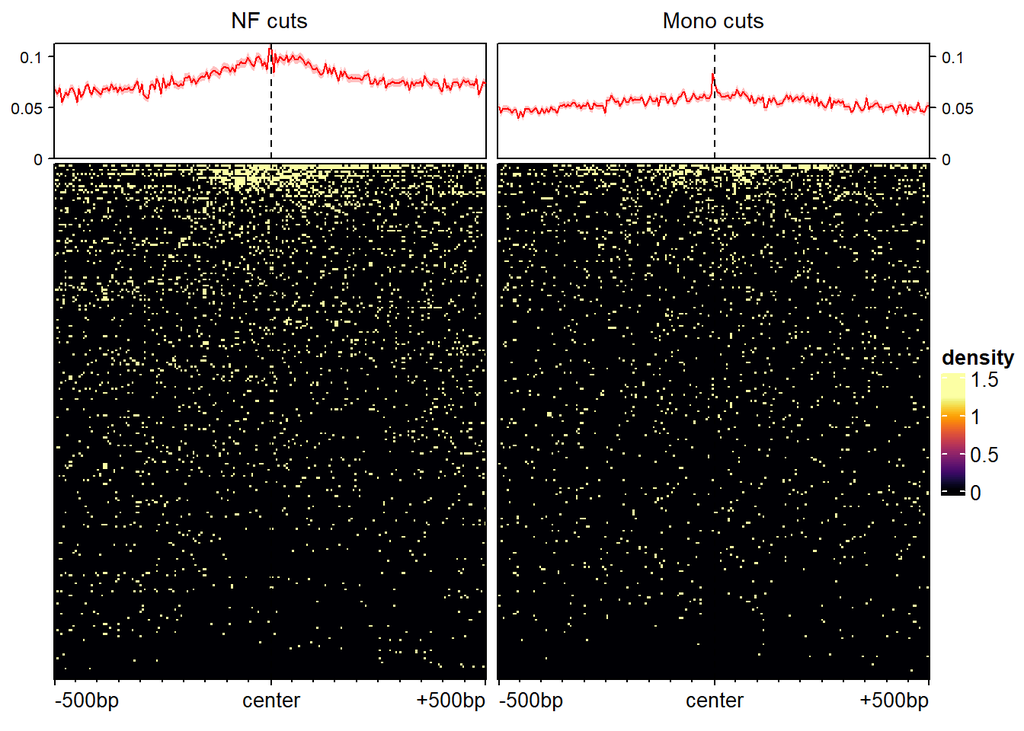

```r
# we prepare the list of tracks
tracks<- c("NF cuts"="NF_cuts.bw", "Mono cuts"="mono_cuts.bw")

# extract signals around the motif occurences
# we zoom in to 500bp around the motif centers, in windows of 5bp
sm_KLF4 <- signal2Matrix(tracks, moi_KLF4, w=5, extend=500)

# plot the signals:
# Renormalizing the results using a background normalization
# this we can do for instance using:
nf_KLF4 <- bwNormFactors(tracks, wsize=5L, useSeqLevels="19", nwind=5000L)
# then we apply the normalization factors:
smb_KLF4 <- rescaleSignalMatrices(sm_KLF4, nf_KLF4)

plotEnrichedHeatmaps(smb_KLF4, trim=0.95)
```

### MAZ

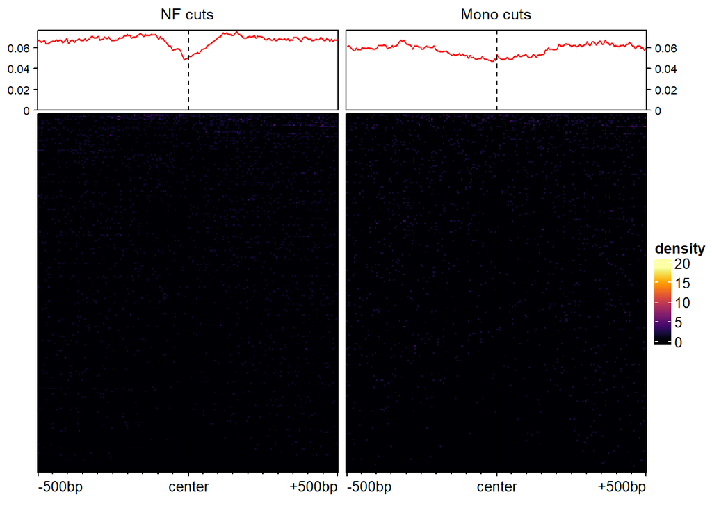

```r
# get MAZ motif
motif_MAZ <- MotifDb::query(MotifDb, c("MAZ","Mus"))[[1]]
motif_MAZ_con <- convert_motifs(motif_MAZ, class="TFBSTools-PFMatrix")

# find motif occurences
moi_MAZ <- motifmatchr::matchMotifs(motif_MAZ_con, chr19, out="positions", p.cutoff=1e-5)[[1]]

# convert to GRanges (when using motifmatchr)
moi_MAZ <- as(setNames(moi_MAZ,names(chr19)), "GRanges")

# extract signals around the motif occurences
# we zoom in to 500bp around the motif centers, in windows of 5bp
sm_MAZ <- signal2Matrix(tracks, moi_MAZ, w=5, extend=500)

# plot the signals:

# using a background normalization
nf_MAZ <- bwNormFactors(tracks, wsize=5L, useSeqLevels="19", nwind=5000L)
# then we apply the normalization factors:
smb_MAZ <- rescaleSignalMatrices(sm_MAZ, nf_MAZ)
plotEnrichedHeatmaps(smb_MAZ, trim=0.95)
```

### KLF4

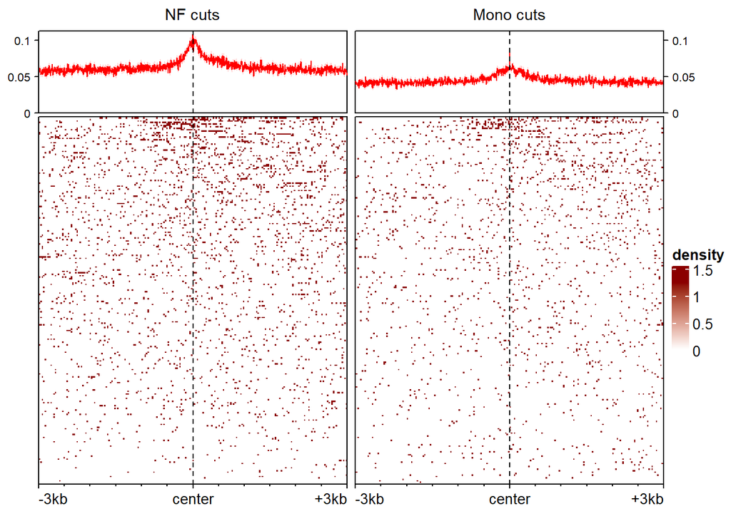

```r
# fetch the protein-coding TSS from chromosome 19
tracks <- c("NF cuts"="NF_cuts.bw", "Mono cuts"="mono_cuts.bw")
txs <- transcripts(ensdb, filter=TxBiotypeFilter("protein_coding"))
txs <- txs[seqnames(txs)=="19"]
tss <- promoters(txs, upstream=0, downstream=1)

tss.sm <- signal2Matrix(tracks, moi_KLF4, w=5, extend=3000)
tss.smb <- rescaleSignalMatrices(tss.sm, nf_KLF4)
plotEnrichedHeatmaps(tss.smb, trim=0.95, colors=c("white","darkred"))
```

### MAZ

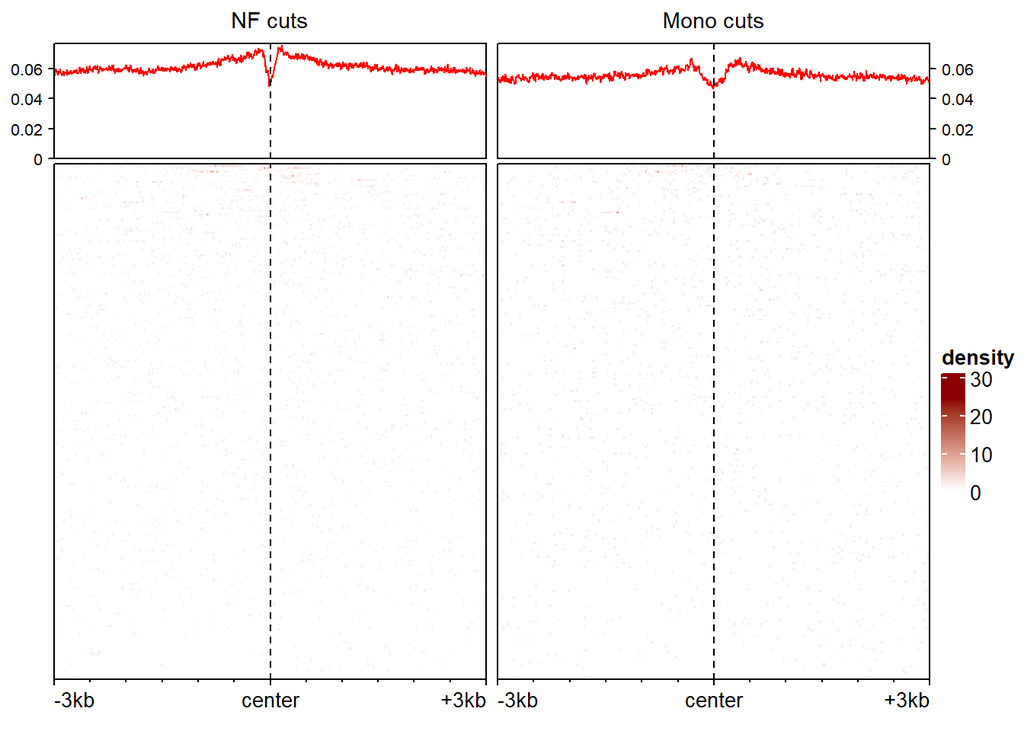

```r
tss2 <- promoters(txs, upstream=0, downstream=1)
tss2.sm <- signal2Matrix(tracks, moi_MAZ, w=5, extend=3000)
tss2.smb <- rescaleSignalMatrices(tss2.sm, nf_MAZ)
plotEnrichedHeatmaps(tss2.smb, trim=0.95, colors=c("white","darkred"))
```